# Theological Classicism in Revolutionary America

Final project for Clio 2

Ancient history was very important to Americans of the late eighteenth and early nineteenth century. Seeped in a pervasive historical culture largely inherited from England, Americans interpreted modern events through the lens of antiquity before, during, and after the American Revolution. Attempting to capture American’s fascination with ancient history during this era, historians have described this historical culture as “the culture of classicism” and the “cult of antiquity.”[^1] This fixation with classical antiquity defined the intellectual atmosphere of early American colleges, making higher education during this time, if not learning itself, inherently classical. As such, much work has been done analyzing the many political pamphlets, speeches, and other published texts that have made explicit connections and reference to hallowed antiquity.

However, as other scholars have shown, the individuals who comprised England’s North American colonies were inheritors of multiple, often conflicting intellectual traditions. Specifically, these individuals were descendants of religious traditions, mainly Protestant, that were equally useful and applicable to contemporary events.[^2] Additionally, the spokespeople of this tradition, mainly the ministers and preachers of local congregations, had themselves come from many of the early colleges and, as a result, had been cast in the classical mold. Indeed, it is perhaps useful to keep in mind that, for many early colleges in America, training future clergy was the primary function of the school. And, like any committed student, they did not forget what they had learned once they had left the classroom behind. The classical concepts, characters, and rhetoric went with them and became woven into the content of their sermons; making the average sermon perhaps the most effective way in which the culture of classicism was spread throughout early America to people and places beyond the reach of the colleges. In analyzing the fifty-five sermons within Liberty Fund’s *Political Sermons of the Founding Era: 1730-1805*, one is able to begin to glimpse the presence of what I am referring to as “theological classicism.” For in their attempt to comprehend the nature of their God and religion’s relation to human governments, ministers turned to classical antiquity.

Yet any study that would attempt to mine for classicism in a set of late eighteenth sermons seems destined for confusion. For ministers of the Revolutionary era, “Rome” was an especially loaded term. Comprised in an atmosphere of heightened anti-Catholicism, came to refer to the seat of the “Man of Sin” and all the evils of popery. One might expect, then, many of the allusions to Rome within these sermons would largely be in reference to the dangers of Catholic influence and not the ancient civilization. However, a cursory review of the sermons revealed that this is not the case. While Rome’s connection to Catholicism is definitely present, equally so are detailed references to antiquity that often go far beyond mere lip service.

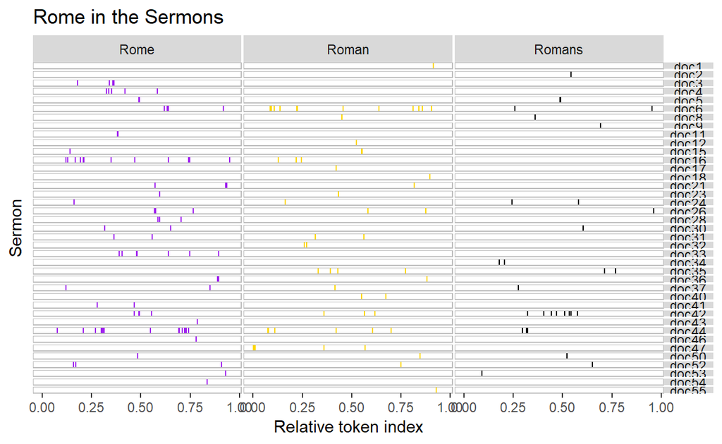

Figure 1: This figure displays the prevalence of Rome as a concept throughout all fifty-five sermons. As was the case with ‘Rome,’ ‘Roman’ and ‘Romans’ were equally loaded terms since it was possible for the former to be in reference to Roman Catholics and the latter the biblical book of the same name. However, in both cases, references to antiquity outnumbered those to more religious topics. Only twelve of forty-six uses of ‘Roman’ were in reference to Catholicism, while, more surprisingly, discussions on ‘Romans’ within these sermons were almost exclusively on the ancient society itself and not on the letter from St. Paul.

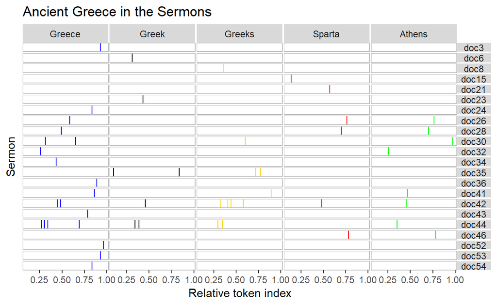

Figure 2: Representing the other half of the American classical mind, this figure shows the prevalence of ancient Greece throughout the fifty-five sermons. It illustrates that although the topic of Greece itself was not as popular as Rome, that did not make it any less present. Not only do many of these occurrences coincide with discussions of Rome but rival the amount of references to some sacred places, such as Jerusalem.

The classicism exhibited by these political sermons went far beyond the more general references to the ancient civilizations as a whole. Frequently, specific classical characters themselves were called out and employed as a means to illustrate the character of God and the truth and effectiveness of the gospel to political society. To get a sense as to how comprehensive this trend was, I have cross-referenced the *Political Sermons* with Meyer Reinhold’s *The Classick Pages*, a study into some of the most popular classical works in Revolutionary America.[^3] Using Reinhold’s study, I constructed a dictionary of the most widely read works that comprised the classical understanding of the late eighteenth and early nineteenth centuries. After the initial comparison, one is surprised with how completely this small sample of early American sermons covered the gamut of classical references. Indeed, in the list of popular classical authors and characters included in Reinhold’s study, the *Political Sermons of the American Founding Era* contained nearly all of them. [^4]

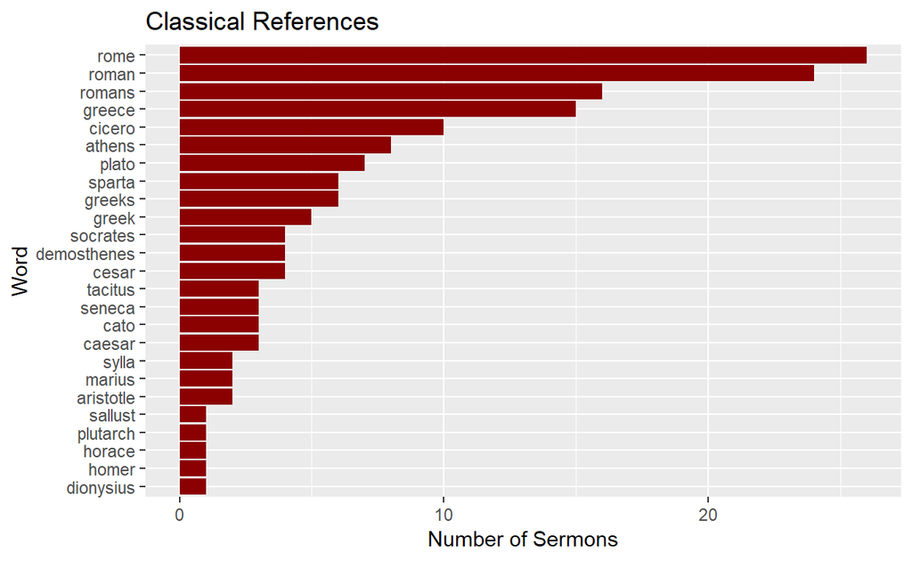

Ministers of the Revolutionary period ultimately displayed a deep sense of classicism. Caroline Winterer has made a distinction between those who possessed “thick” and “thin” classicism: those who had “little formal learning” of antiquity and possessed a thin understanding of the classics, and those who possessed a thick knowledge from a “deep, lifelong study” of classicism. [^5] Yet while scholars like Winterer typically reserve the deep understanding of antiquity as the domain of politicians and elite instructors, these sermons appear to be more thoroughly saturated in the classics than even some of the leading political pamphlets of the era, including Thomas Paine’s *Common Sense* and *Age of Reason*.

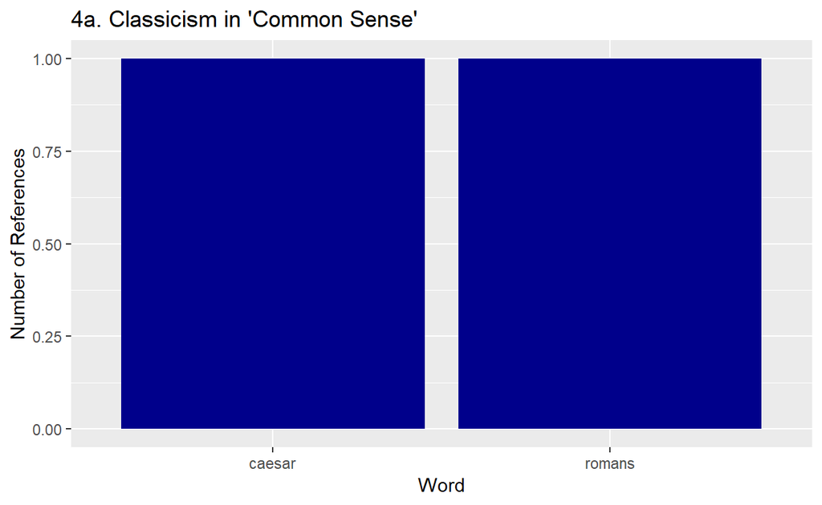

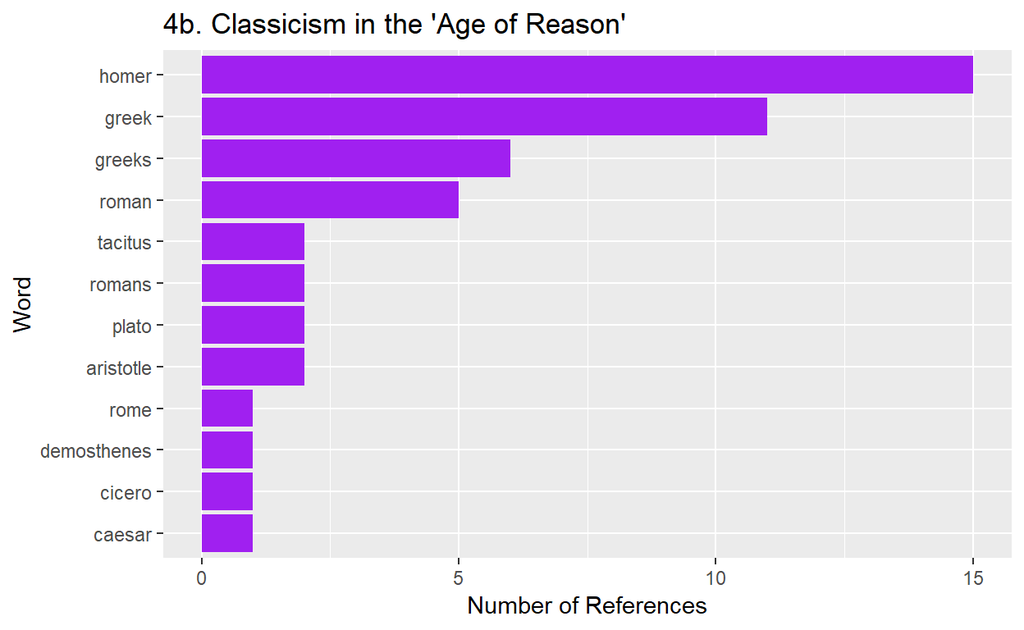

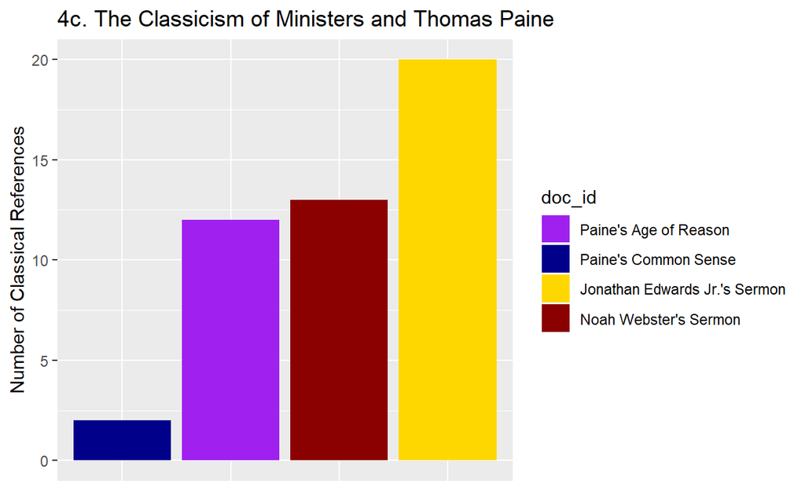

Figure 4: These figures show the heightened classicism of sermons over some of the most popular pamphlets of the era. Although figure 4a almost seems superfluous, which represents the results of sending Paine’s *Common Sense* through the classical dictionary from Reinhold, which contained only two references with one use each, it serves as an instructive visual when compared to the breadth and quantity of references in figure 3. And while *Common Sense* was released several generations prior, each of the other three documents shown here were published in the same year, 1794. Not only are ancient references more ‘thin’ in Paine’s work, figures 4a and 4b, juxtaposed to the breadth in the sermons, shown in figure 3, neither of Paine’s works relied on classical concept as heavily as Jonathan Edwards Jr. and Noah Webster.

As was the case for many of their political counterparts, ministers and theologians of the late eighteenth century developed their thick classicism from the colleges and universities they attended. Consequently, this may account for the discrepancy in classical references between Paine’s works and some of the sermons from this era, since Paine himself had little formal education. However, it is the popularity of Paine’s works and political sermons that bind the two together. The argument to be made is that if there was such a culture of “thin” classicism, where antiquity was made available to a broader, uneducated audience and then used to supply a “common set of symbols, knowledge, and ideas” that “facilitated discourse,” it certainly did not originate from the likes of Thomas Paine. [^6] It had to have been nurtured elsewhere.

Although I will initially suggest that the culture of thin classicism originated in the sermons of local ministers, I am hesitant to do so for several reasons. First, and most simply, while analyzing *The Political Sermons* is useful in crafting further questions regarding theological classicism, the collection itself is too small to make such a sweeping claim. Indeed, the sermons delivered and published in any one of the given years the *Political Sermons* covers far outweigh the collection as a whole. As such, a more comprehensive study would need to be undertaken in order to credit America’s public classicism to its early ministers.

Second, and more importantly, I am hesitant to argue that the culture of classicism originated within the bounds of theological classicism because the latter presented an incredibly different kind of classical image than what scholars have recently analyzed. In other words, historians who have delved into the life of antiquity in early American culture have shown how classical Greece and Rome were seen, in many ways, as model republics. Although there were individual characters or aspects within each that early Americans were taught to shun, or “antimodels,” as Carl Richard has termed them, overwhelmingly the societies themselves where put forth in the most radiant light.[^7] Ministers, however, rarely shared this sentiment. Indeed, in some ways, theological classicism presented the opposite mindset in which certain aspects and characters, such as Cicero, could be held up as laudable, but the ancient, “pagan” societies of Greece and Rome as a whole were seen as the antimodels.

The 1794 sermons of Jonathan Edwards Jr. and Noah Webster provide a closer look into the images theological classicism put forth. Edwards opened the longest portion of his sermon by harkening readers back to the ancient past. “Let us compare,” he began, “those ancient heathens, of whom we know the most and who were the most improved and polite, with the Christians of whom we know the most; the antient Greeks and Romans with the citizens of the United States.” [^8] Edwards then delved into a comparative analysis of how well kept the chief societal and political virtues were in each society. In doing so, he traversed through an immense portion of the classical realm, including the stoicism of Cato and Zeno and the lewdness of Virgil and Homer. In the course of the sermon, he would extrapolate on the ideas of Xenophon, Solon, Cicero, Seneca, and the political and cultural atmosphere of Rome and Greece themselves. Yet, while the detail into which Edwards plunged is impressive, it was all to drive home his main point: that the ancients were a horrible, vice ridden society and thanks be to God that Christianity came along to save the political life of republics.

Noah Webster employed similar classical depth to paint largely the same image of classical antiquity. Delving into the bloody story of Lucius Cornelius Sulla and Gaius Marius, Webster portrayed ancient Rome as a violent, chaotic state whose most important political maxim was to repel force with force.[^9] As was the case with Edwards, Webster’s approach and detail on hist subject illustrated the blurred line that seemed to exist for ministers between their role as preachers and historians. And, as historians, ministers of the Revolutionary era portrayed a very different image of classical antiquity than the accounts that appeared in newspapers, periodicals, and books that modern scholars have studied. Gauging the effectiveness of theological classicism in spreading the cult of antiquity throughout early America thus requires not only a study into the breadth of history ministers presented their flocks, but into how prevalent their kind of classicism was in shaping the public conceptions of Greece and Rome.

[^1]: Caroline Winterer, *The Culture of Classicism: Ancient Greece and Rome in American Intellectual Life, 1780-1910* (Johns Hopkins University Press, 2002), 15-29; Meyer Reinhold, *The Classick Pages: Classical Reading of Eighteenth-Century Americans* (Pennsylvania State University: American Philological Association, 1975), 1. See also Carl Richard, *The Founders and the Classics: Greece, Rome, and the Enlightenment* (Harvard University Press, 1994).
[^2]: Nathan Perl-Rosenthal, “The ‘Divine Right of Republics’: Hebraic Republicanism and the Debate over Kingless Government in Revolutionary America,” *The William and Mary Quarterly*, Vol. 66, No. 3 (2009); Carla Pestana, *Protestant Empire: Religion and the Making of the British Atlantic World* (University of Pennsylvania Press, 2010); Eran Shalev, *American Zion: The Old Testament as a Political Text from the Revolution to the Civil War* (New Haven: Yale University Press, 2013).
[^3]: Reinhold, *The Classick Pages* (1975).
[^4]: The only names the sermons omitted were Ovid, Polybius, and, more surprisingly, Livy.
[^5]: Caroline Winterer, “Model Empire, Lost City: Ancient Carthage and the Science of Politics in Revolutionary America,” *The William and Mary Quarterly*, Vol. 67. No. 1 (2010), 23-24.
[^6]: Richard, *The Founders and the Classics* (1994), 10.
[^7]: Richard, *The Founders and the Classics* (1994), 85.
[^8]: Jonathan Edwards, Jr, “The Necessity of the Belief of Christianity,” *Political Sermons of the American Founding Era, 1730-1805* (Indianapolis: Liberty Fund, 1990), 1199.
[^9]: Noah Webster, “The Revolution in France,” *Political Sermons* (1990), 1281. Webster used this account to describe what he saw as the similar state of France at the time. The other instances in which he discussed antiquity were equally unflattering.